# Identificação e Análise de Oportunidades Tecnológicas e Territoriais

Empreendedorismo Tecnológico e Desenvolvimento Territorial · Aula 08

Prof. Dr. Luiz Diego Vidal Santos

## Unidade II Visão Geral da Aula

Roteiro da aula · 4 horas Tópicos estruturantes

1. Descoberta vs. Criação de oportunidades (Alvarez & Barney, 2007).
2. Conhecimento prévio e reconhecimento de padrões (Shane, 2000; Baron, 2006).
3. Fontes de oportunidades tecnológicas e territoriais (Drucker, 1985).
4. Critérios de avaliação e triagem de oportunidades (TAM/SAM/SOM).
5. Propriedade Intelectual e liberdade de operação (*Freedom to Operate*).

Objetivo central Identificação e triagem

Compreender os mecanismos cognitivos, informacionais e institucionais pelos quais **oportunidades de novos negócios** são identificadas ou criadas, e aplicar ferramentas de avaliação de atratividade mercadológica e proteção tecnológica.

**Critério territorial:** transformar sinais locais e conhecimento científico em oportunidades verificáveis e protegidas.

# Natureza das Oportunidades

## Conceito Descoberta vs. Criação (Alvarez & Barney, 2007)

| Dimensão | Teoria da Descoberta | Teoria da Criação |
| --- | --- | --- |
| **Natureza da oportunidade** | Existe objetivamente no mercado (choques exógenos) | É construída endogenamente pela ação do empreendedor |
| **Informação** | Assimétrica, mas passível de pesquisa | Incerta; emerge apenas na interação |
| **Estratégia** | Planejamento e análise de risco | Experimentação iterativa e aprendizado |

Corredores informacionais Conhecimento Prévio (Shane, 2000)

Experiências anteriores em mercados, formas de atender clientes e problemas específicos explicam por que atores diferentes veem oportunidades distintas.

Cognição empreendedora Reconhecimento de Padrões (Baron, 2006)

Empreendedores conectam “pontos” aparentemente dispersos: tendências demográficas, regulação ambiental e avanços técnicos.

# Fontes e Triagem de Oportunidades

## Método As 7 Fontes de Inovação (Drucker) e TAM/SAM/SOM

Drucker, 1985 Fontes internas e externas de sinais

1. O **inesperado** (sucesso ou fracasso imprevisto);
2. **Incongruências** entre realidade e expectativa;
3. **Necessidades de processo** (gargalos técnicos);
4. **Mudanças na estrutura** da indústria ou mercado;
5. **Demografia** (envelhecimento, urbanização, migração);
6. **Mudanças de percepção** (sustentabilidade, rastreabilidade);
7. **Novo conhecimento** científico e não científico.

Dimensionamento Funil TAM · SAM · SOM

- **TAM (*Total Addressable Market*):** demanda total teórica da solução.
- **SAM (*Serviceable Available Market*):** parcela alcançável pelo modelo de negócio e geografia.
- **SOM (*Serviceable Obtainable Market*):** parcela realista capturável no curto e médio prazo.

**Erro Clássico:** confundir o TAM global com o mercado acessível (SOM) de uma *startup* regional nos primeiros 3 anos.

## Síntese Esquema: TAM / SAM / SOM e Triagem de PI

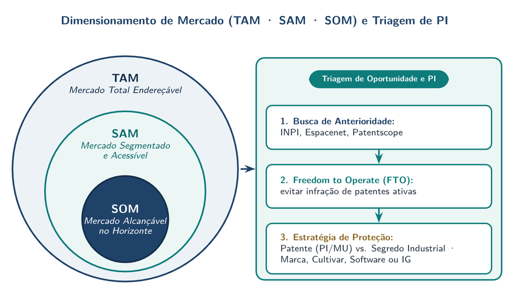

Dimensionamento progressivo de mercado (TAM, SAM, SOM) e roteiro de triagem de Propriedade Intelectual e Liberdade de Operação (FTO).

Do funil de mercado à estratégia de Propriedade Intelectual Integração entre recorte realista de demanda (SOM) e verificação prévia de anterioridade e FTO

A atratividade de uma oportunidade territorial exige convergência entre mercado acessível comprovável e liberdade jurídica para operar.

# Proteção e Liberdade de Operação

## Conceito Propriedade Intelectual na Avaliação de Oportunidades

Apropriabilidade tecnológica Ativos intangíveis estratégicos

- **Patentes (PI e MU):** exclusividade temporária (20 / 15 anos) mediante divulgação técnica.
- **Segredo Industrial:** proteção sem divulgação enquanto mantido sob sigilo.
- **Cultivares, Marcas, *Software* e Desenho Industrial.**
- **Indicações Geográficas:** proteção coletiva territorial.

Due diligence técnica Busca de anterioridade e FTO

- **Estado da Técnica:** verificar no INPI, Espacenet e Patentscope se a solução já existe antes de investir em P&D.
- **Liberdade de Operação (*Freedom to Operate — FTO*):** garantir que a tecnologia não infringe patentes vigentes de terceiros no território de comercialização.

**Atenção prática:** publicar artigo ou apresentar protótipo antes do depósito pode destruir o requisito de novidade da patente.

# Oficina e Leituras

## Método Matriz de Atratividade da Oportunidade (40 min)

Checklist de avaliação · escala 1 a 5 Critérios para a oportunidade territorial

1. **Dor do cliente:** urgência real do problema territorial;
2. **Mercado acessível:** tamanho e crescimento do SAM/SOM;
3. **Vantagem técnica:** barreiras de imitação (PI ou *know-how*);
4. **Viabilidade:** aderência regulatória e ambiental;
5. **Alinhamento:** aderência às competências da equipe e do ecossistema local.

Preparação · Aula 09 Leituras para a próxima aula

- **OSTERWALDER, A.; PIGNEUR, Y.** *Business Model Generation* (Parte 1: O Canvas).
- **RIES, E.** *A Startup Enxuta* (Caps. sobre MVP e Aprendizado Validado).
- **BLANK, S.** *Why the Lean Start-Up Changes Everything*. HBR, 2013.